# Original Attempt

This assignment's goal is to construct a convolutional network using a data set that includes images of dogs and cats. In this case, the model attempts to identify the characteristics of these photos in order to accurately and quickly classify unknown images.

Concerning Dataset

1. Consider the Cats & Dogs example. Start initially with a training sample of 1000, a validation sample of 500, and a test sample of 500 (like in the text). Use any technique to reduce overfitting and improve performance in developing a network that you train from scratch. What performance did you achieve?

```python
import numpy as np
import tensorflow as tf
random_numbers = np.random.normal(size=(1000, 16))
dataset = tf.data.Dataset.from_tensor_slices(random_numbers)
```

```python
for i, element in enumerate(dataset):
    print(element.shape)
    if i >= 2:
        break
```

```
(16,)
(16,)
(16,)
```

```python
batched_dataset = dataset.batch(32)
for i, element in enumerate(batched_dataset):
    print(element.shape)
    if i >= 2:
        break
```

```
(32, 16)
(32, 16)
(32, 16)
```

```python
reshaped_dataset = dataset.map(lambda x: tf.reshape(x, (4, 4)))
for i, element in enumerate(reshaped_dataset):
    print(element.shape)
    if i >= 2:
        break
```

```
(4, 4)
(4, 4)
(4, 4)
```

```python
for data_batch, labels_batch in train_dataset:
    print("data batch shape:", data_batch.shape)
    print("labels batch shape:", labels_batch.shape)
    break
```

```
data batch shape: (32, 180, 180, 3)
labels batch shape: (32,)
```

```python
**Data preprocessing**

The preprocessing involved reshaping the dataset and augmenting the training data using TensorFlow's ImageDataGenerator. This augmentation
included random rotations, shifts, shears, zooms, flips, and rescaling, which helps the model generalize better by presenting varied
versions of the training images.
```

### Building the model

** Developing an experimental network for the classification of dogs verses cats **

```python
A pre-trained MobileNetV2 model excluding the top layer was used as a base. The base layers were frozen to prevent their weights from being
updated during training, which is a common practice when using transfer learning to take advantage of previously learned patterns.

A new top layer, specifically a GlobalAveragePooling2D layer followed by a Dense layer with a sigmoid activation function, was added to
perform binary classification (dog vs. cat). The model was compiled with the Adam optimizer and a learning rate of 0.0001, using binary
cross-entropy as the loss function.
```

```
Found 1002 images belonging to 2 classes.
Found 498 images belonging to 2 classes.
```

```
31/31 ━━━━━━━━━━━━━━━━━━━━ 10s 242ms/step - accuracy: 0.3137 - loss: 1.0376 - val_accuracy: 0.3271 - val_loss: 0.9460
31/31 ━━━━━━━━━━━━━━━━━━━━ 0s 4ms/step - accuracy: 0.4375 - loss: 0.4094 - val_accuracy: 0.4444 - val_loss: 0.4465
```

[output not shown]

```
31/31 ━━━━━━━━━━━━━━━━━━━━ 7s 213ms/step - accuracy: 0.4427 - loss: 0.8353 - val_accuracy: 0.5000 - val_loss: 0.7570
31/31 ━━━━━━━━━━━━━━━━━━━━ 0s 3ms/step - accuracy: 0.5000 - loss: 0.3914 - val_accuracy: 0.5556 - val_loss: 0.3581
```

[output not shown]

```
31/31 ━━━━━━━━━━━━━━━━━━━━ 7s 208ms/step - accuracy: 0.5964 - loss: 0.6870 - val_accuracy: 0.6104 - val_loss: 0.6624
31/31 ━━━━━━━━━━━━━━━━━━━━ 0s 3ms/step - accuracy: 0.6250 - loss: 0.3452 - val_accuracy: 0.5556 - val_loss: 0.3642
```

[output not shown]

```
31/31 ━━━━━━━━━━━━━━━━━━━━ 7s 213ms/step - accuracy: 0.6953 - loss: 0.5740 - val_accuracy: 0.7521 - val_loss: 0.5418
31/31 ━━━━━━━━━━━━━━━━━━━━ 0s 3ms/step - accuracy: 0.7188 - loss: 0.3219 - val_accuracy: 0.5556 - val_loss: 0.3398
```

[output not shown]

```
31/31 ━━━━━━━━━━━━━━━━━━━━ 8s 216ms/step - accuracy: 0.7566 - loss: 0.5261 - val_accuracy: 0.7917 - val_loss: 0.4717
31/31 ━━━━━━━━━━━━━━━━━━━━ 0s 3ms/step - accuracy: 0.8750 - loss: 0.1846 - val_accuracy: 0.8889 - val_loss: 0.2048
```

[output not shown]

```
31/31 ━━━━━━━━━━━━━━━━━━━━ 7s 211ms/step - accuracy: 0.8189 - loss: 0.4344 - val_accuracy: 0.8604 - val_loss: 0.4048
31/31 ━━━━━━━━━━━━━━━━━━━━ 0s 3ms/step - accuracy: 0.9062 - loss: 0.1766 - val_accuracy: 0.6667 - val_loss: 0.2343
```

[output not shown]

```
31/31 ━━━━━━━━━━━━━━━━━━━━ 7s 209ms/step - accuracy: 0.8590 - loss: 0.4028 - val_accuracy: 0.8687 - val_loss: 0.3679
31/31 ━━━━━━━━━━━━━━━━━━━━ 0s 3ms/step - accuracy: 0.8438 - loss: 0.2131 - val_accuracy: 0.9444 - val_loss: 0.1329
```

[output not shown]

```
31/31 ━━━━━━━━━━━━━━━━━━━━ 7s 208ms/step - accuracy: 0.8889 - loss: 0.3536 - val_accuracy: 0.8854 - val_loss: 0.3472
```

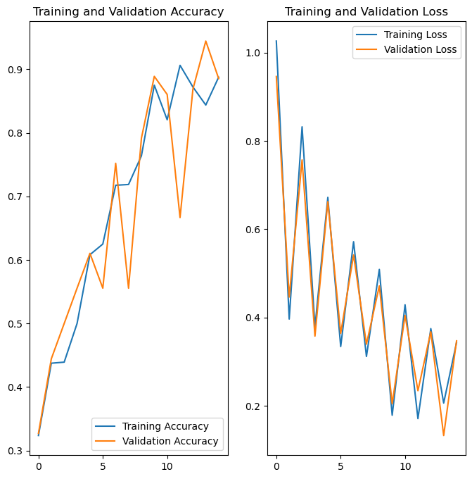

```python
import numpy as np
import tensorflow as tf
from tensorflow.keras import layers, models
from tensorflow.keras.preprocessing.image import ImageDataGenerator
from tensorflow.keras.applications import MobileNetV2
from tensorflow.keras.optimizers import Adam
import matplotlib.pyplot as plt
from sklearn.metrics import classification_report, confusion_matrix

# Paths to your data directories
train_dir = "/Users/palanchasushma/Documents/Advanced Machine Learning/AML ASSIGNMENT 3/Data/Train"
test_dir = "/Users/palanchasushma/Documents/Advanced Machine Learning/AML ASSIGNMENT 3/Data/Test"

# Initialize ImageDataGenerator with data augmentation for the training dataset
train_datagen = ImageDataGenerator(
    rescale=1./255,
    rotation_range=20,
    width_shift_range=0.1,
    height_shift_range=0.1,
    shear_range=0.1,
    zoom_range=0.2,
    horizontal_flip=True,
    fill_mode='nearest',
    validation_split=0.3333  # Validation split
)

test_datagen = ImageDataGenerator(rescale=1./255)  # Only rescaling for test data

# Load images from directories
train_generator = train_datagen.flow_from_directory(
    train_dir,
    target_size=(160, 160),  # Adjusted to match MobileNetV2 default
    batch_size=32,
    class_mode='binary',  # Use 'categorical' for more than 2 classes
    subset='training'
)

validation_generator = train_datagen.flow_from_directory(
    train_dir,
    target_size=(160, 160),  # Adjusted to match MobileNetV2 default
    batch_size=32,
    class_mode='binary',
    subset='validation'
)

# Load the MobileNetV2 model pre-trained on ImageNet data but exclude the top (classification) layer
base_model = MobileNetV2(weights='imagenet', include_top=False, input_shape=(160, 160, 3))

# Freeze the base model layers to not train them
base_model.trainable = False

# Define the model
model = models.Sequential([
    base_model,
    layers.GlobalAveragePooling2D(),
    layers.Dense(1, activation='sigmoid')  # Use 'softmax' for categorical
])

# Compile the model with the corrected learning_rate parameter
model.compile(optimizer=Adam(learning_rate=0.0001),
              loss='binary_crossentropy',
              metrics=['accuracy'])

# Fit the model for 15 epochs
history = model.fit(
    train_generator,
    steps_per_epoch=train_generator.samples // train_generator.batch_size,
    epochs=15,
    validation_data=validation_generator,
    validation_steps=validation_generator.samples // validation_generator.batch_size
)

# Plotting training and validation accuracy and loss
acc = history.history['accuracy']
val_acc = history.history['val_accuracy']
loss = history.history['loss']
val_loss = history.history['val_loss']

epochs_range = range(len(acc))

plt.figure(figsize=(8, 8))
plt.subplot(1, 2, 1)
plt.plot(epochs_range, acc, label='Training Accuracy')
plt.plot(epochs_range, val_acc, label='Validation Accuracy')
plt.legend(loc='lower right')
plt.title('Training and Validation Accuracy')

plt.subplot(1, 2, 2)
plt.plot(epochs_range, loss, label='Training Loss')
plt.plot(epochs_range, val_loss, label='Validation Loss')
plt.legend(loc='upper right')
plt.title('Training and Validation Loss')
plt.show()
```